# Loch outlet flux analysis

Bella Oleksy

2024-11-19

# Some notes at the top about data processing

**Flux estimates–** For each day, I have a solute concentration and a discharge value solute = mg/L; discharge = m3/s

Concentrations are interpolated between weeks as in Mast et al. 2014 ES&T

- [mg/L] * [m3/s] * [1000L/m3] * [86400s/day] = units of [kg/week]
- Divide by the area of the watershed (660ha) and you get [kg/ha/week]
- From there I summed across all weeks to get all annual yields (kg/ha/yr)

### Missing data:

Missing data are sprinkled throughout, but basically a non-issue after 1991. I interpolated between weeks with missing data where necessary but this is extremely rare after 1991. We do not have data past 2023 in the database yet.

I linearly interpolated missing Loch outlet chemistry values between sampling trips up with up to 30 days of missing data. Beyond that, I did not interpolate and those are in the dataset as NAs.

There’s still some 2019 NO3 data missing that I will ask MJ’s help to track down.

Summer data are robust 1991-2022

### Test for annual export trends

Mann-Kendell test with Sens Slope

| chem_name | slope | p.value | trend | intercept | time_frame |
| --- | --- | --- | --- | --- | --- |
| NH4-N | 0.003 | 0.0296 | increasing | -5.2 | annual |
| NO3-N | -0.01 | 0.3768 | no trend | 21.4 | annual |
| SO4-S | 0.02 | 0.0771 | no trend | -35.5 | annual |
| SiO2 | 0.02 | 0.8918 | no trend | -22.8 | annual |
| cations | 0.07 | 0.3242 | no trend | -123 | annual |
| NH4-N | 0.002 | 0.0093 | increasing | -3.21 | summer |
| NO3-N | 0.004 | 0.6336 | no trend | -5.77 | summer |
| SO4-S | 0.02 | 0.0701 | no trend | -36.8 | summer |
| SiO2 | 0.084 | 0.145 | no trend | -158 | summer |
| cations | 0.085 | 0.0397 | increasing | -158 | summer |
| NH4-N | 0.001 | 0.0127 | increasing | -1.94 | June |
| NO3-N | 0.002 | 0.5399 | no trend | -3.25 | June |
| SO4-S | 0.01 | 0.062 | no trend | -18.4 | June |
| SiO2 | 0.069 | 0.0246 | increasing | -131 | June |
| cations | 0.058 | 0.0325 | increasing | -108 | June |
| NH4-N | 0.001 | 0.0079 | increasing | -1.52 | July |
| NO3-N | 0 | 0.9674 | no trend | 0.749 | July |
| SO4-S | 0.006 | 0.0483 | increasing | -11.6 | July |
| SiO2 | 0.007 | 0.6143 | no trend | -11.4 | July |
| cations | 0.02 | 0.236 | no trend | -36 | July |
| NH4-N | 0 | 0.0886 | no trend | -0.762 | August |
| NO3-N | 0 | 0.924 | no trend | 0.323 | August |
| SO4-S | 0.004 | 0.145 | no trend | -7.02 | August |
| SiO2 | -0.004 | 0.8381 | no trend | 9.64 | August |
| cations | 0.013 | 0.2943 | no trend | -23.3 | August |

## Plots

### Annual fluxes 1991-2022

There is only a trend line on the plot if p < 0.05.

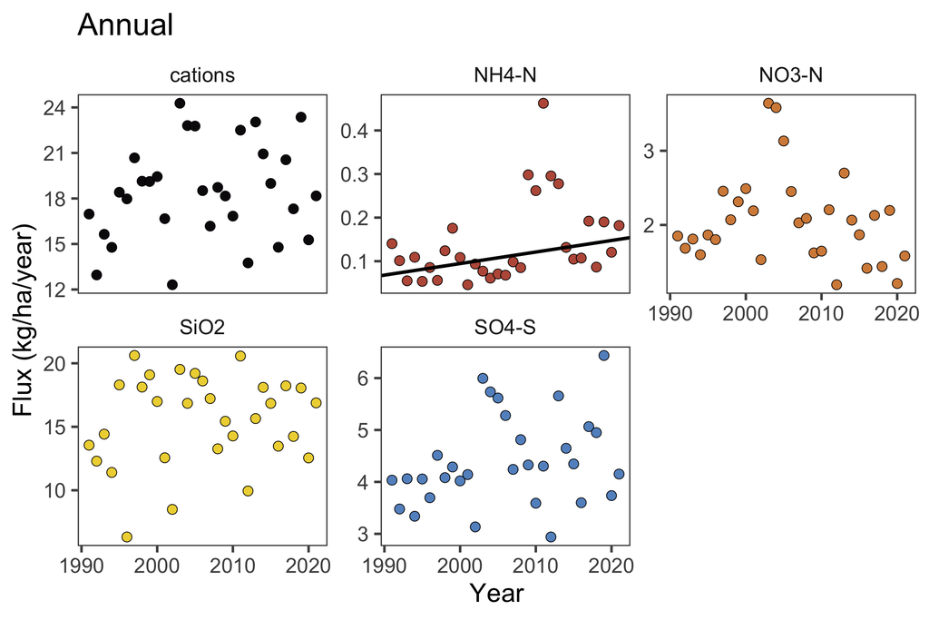

### Monthly fluxes 1984-2022

There is only a trend line on the plot if p < 0.05.

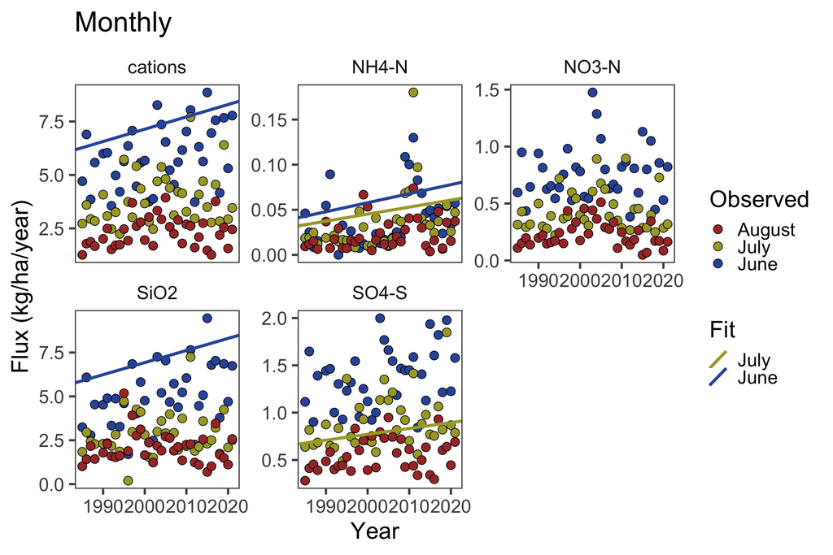

### Summer fluxes 1984-2022

There is only a trend line on the plot if p < 0.05.

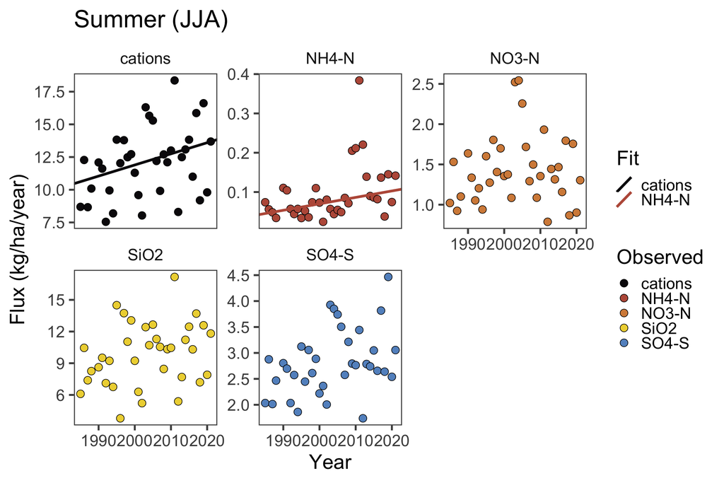